# 用户基础维度分析

## 导入相关的

```python
import pandas as pd
import matplotlib.pyplot as plt
import numpy as np

pd.__version__, np.__version__
```

```
('1.3.2', '1.20.3')
```

```python
plt.rcParams['font.sans-serif'] = ['SimHei']  #设置中文字体为黑体
plt.rcParams['axes.unicode_minus'] = False #正常显示负号

pd.set_option('display.float_format',lambda x : '%.2f' % x)#pandas禁用科学计数法

#忽略警告
import warnings
warnings.filterwarnings('ignore')
```

## 加载数据

```python
data = pd.read_csv('./dataclean.csv')
data.head(3)
```

|  | order_id | product_id | category_id | category_code | brand | price | user_id | age | sex | local | datetime | buy_cnt | amount |
| --- | --- | --- | --- | --- | --- | --- | --- | --- | --- | --- | --- | --- | --- |
| 0 | 2318945879811162983 | 2309018204833317816 | 2268105479144079872.00 | M | compliment | 0.56 | 1515915625465863936.00 | 28.00 | 女 | 浙江 | 2020-05-28 09:58:32 | 4 | 2.24 |
| 1 | 2295740594749702229 | 1515966223509104892 | 2268105428166508800.00 | electronics.smartphone | apple | 1387.01 | 1515915625448766464.00 | 21.00 | 男 | 北京 | 2020-04-26 09:33:47 | 4 | 5548.04 |
| 2 | 2388440981134674698 | 1515966223509106757 | 2360741867017995776.00 | appliances.environment.air_conditioner | samsung | 366.41 | 1515915625514599680.00 | 50.00 | 男 | 广东 | 2020-11-16 04:38:43 | 4 | 1465.64 |

```python
data.shape, data.user_id.nunique()
```

```
((535065, 13), 92755)
```

共有92755名用户信息

## 基础维度分析

### 地域维度分析

```python
local = data.groupby('local')['user_id'].nunique().reset_index()
local = local.rename(columns={'user_id':'用户数量'})
local = local.sort_values('用户数量').reset_index(drop=True)

local
```

|  | local | 用户数量 |
| --- | --- | --- |
| 0 | 湖南 | 5330 |
| 1 | 天津 | 5337 |
| 2 | 重庆 | 5342 |
| 3 | 湖北 | 5355 |
| 4 | 浙江 | 5370 |
| 5 | 四川 | 5445 |
| 6 | 海南 | 5449 |
| 7 | 江苏 | 5561 |
| 8 | 北京 | 15928 |
| 9 | 上海 | 16031 |
| 10 | 广东 | 21382 |

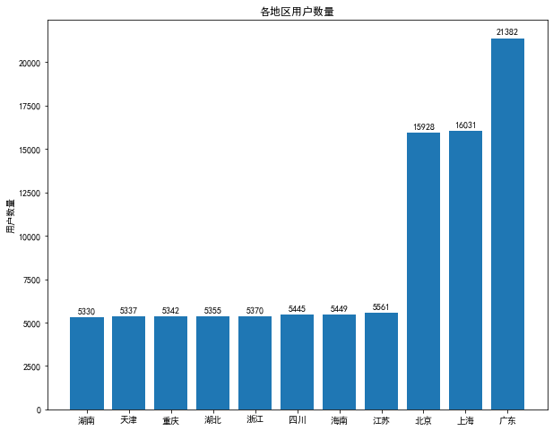

```python
plt.figure(figsize=(10,8))
plt.ylabel('用户数量')
plt.title('各地区用户数量')
plt.bar(local['local'],local['用户数量'])
for x,y in enumerate(local['用户数量']):
    plt.text(x,y+200,y,ha='center')
plt.show()
```

广东的用户数量是最多的，然后就是上海和北京，其他八个城市用户数比较平均，都在5400左右。

### 性别维度

#### 性别分布

```python
sex =  data.groupby('sex')['user_id'].nunique().reset_index()
sex.rename(columns={'user_id':'用户数量'},inplace=True)
sex
```

|  | sex | 用户数量 |
| --- | --- | --- |
| 0 | 女 | 47235 |
| 1 | 男 | 47628 |

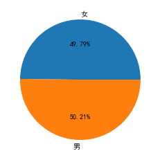

```python
plt.pie(sex['用户数量'],labels=sex['sex'],autopct='%1.2f%%')
plt.show()
```

从性别维度来看，男女性分布较为平均

#### 不同性别消费差异

```python
data.columns
```

```
Index(['order_id', 'product_id', 'category_id', 'category_code', 'brand',
       'price', 'user_id', 'age', 'sex', 'local', 'datetime', 'buy_cnt',
       'amount'],
      dtype='object')
```

```python
#比较不同性别下的消费金额与下单次数均值
sex_data = data.groupby('sex').agg(消费金额=('amount','sum'),下单次数=('order_id','nunique'))
sex_data
```

| sex | 消费金额 | 下单次数 |
| --- | --- | --- |
| 女 | 57108456.57 | 192394 |
| 男 | 57878179.31 | 196348 |

发现男性女性的消费金额与下单次数比较平均

### 年龄维度

#### 年龄分布

```python
age = data.groupby('age')['user_id'].nunique().reset_index()
age.rename(columns={'user_id':'用户数量'},inplace=True)
```

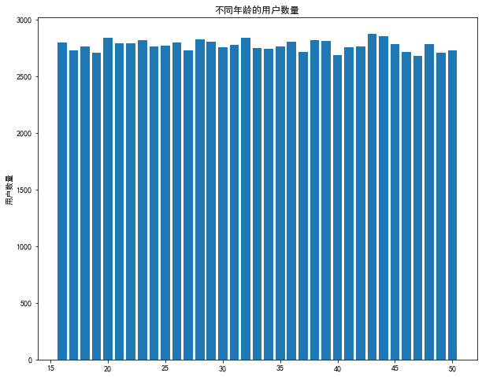

```python
plt.figure(figsize=(10,8))
plt.ylabel('用户数量')
plt.title('不同年龄的用户数量')
plt.bar(age['age'],age['用户数量'])

plt.show()
```

对年龄维度绘制条形图发现年龄分布还是比较均匀的，但是由于年龄过多，导致无法看清楚数据，考虑对年龄进行分箱

#### 年龄段分布

```python
#先看一下年龄维度的极值
data.age.min(), data.age.max()
```

```
(16.0, 50.0)
```

```python
#对年龄进行分箱处理
bins = range(15, 51, 5)
labels = [f'({bins[i]}-{bins[i+1]})岁' for i, x in enumerate(bins) if i <len(bins)-1]

age_data = data.copy()

age_data['age_bin'] = pd.cut(x=age_data.age, bins=bins, right=True, labels=labels)
```

```python
age = age_data.groupby(by='age_bin')['user_id'].nunique().reset_index()
age.rename(columns={'user_id':'用户数量'}, inplace=True)
age
```

|  | age_bin | 用户数量 |
| --- | --- | --- |
| 0 | (15-20)岁 | 13726 |
| 1 | (20-25)岁 | 13867 |
| 2 | (25-30)岁 | 13831 |
| 3 | (30-35)岁 | 13802 |
| 4 | (35-40)岁 | 13775 |
| 5 | (40-45)岁 | 13969 |
| 6 | (45-50)岁 | 13535 |

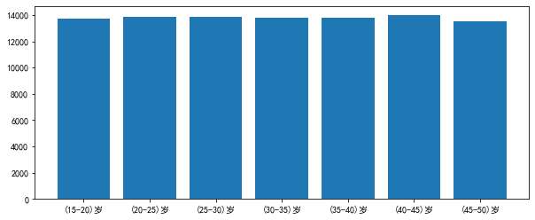

```python
plt.figure(figsize=(10,4))
plt.bar(age['age_bin'], age['用户数量'])
plt.show()
```

各个年龄段的人数分布比较平均

#### 不同年龄消费差异

```python
age_bin_data = age_data.groupby('age_bin').agg(消费金额=('amount','sum'), 下单次数=('order_id','nunique'))
age_bin_data
```

| age_bin | 消费金额 | 下单次数 |
| --- | --- | --- |
| (15-20)岁 | 16007287.18 | 54302 |
| (20-25)岁 | 16500743.70 | 55546 |
| (25-30)岁 | 16513446.00 | 54723 |
| (30-35)岁 | 17004578.70 | 58275 |
| (35-40)岁 | 14995577.44 | 49744 |
| (40-45)岁 | 17078724.54 | 59067 |
| (45-50)岁 | 16886278.32 | 57085 |

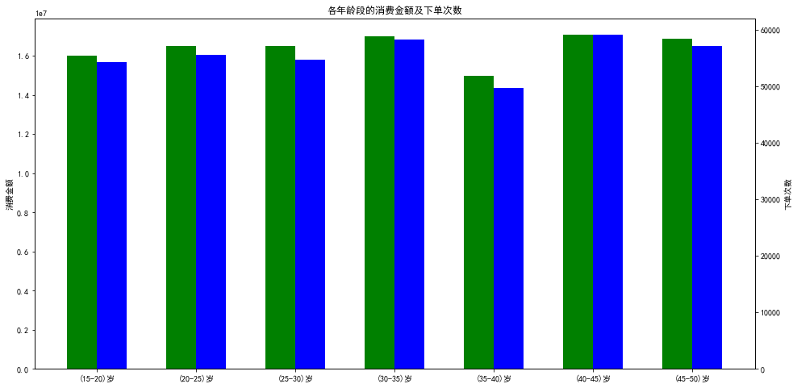

```python
fig,ax1 = plt.subplots(figsize=(16,8))
xticks = np.arange(len(age_bin_data.index))

ax1.bar(xticks,age_bin_data.消费金额,width=0.3,color='g')
ax1.set_ylabel('消费金额')
ax2 = ax1.twinx()

ax2.bar(xticks+0.3,age_bin_data.下单次数,width=0.3,color='b')
ax2.set_ylabel('下单次数')
plt.title('各年龄段的消费金额及下单次数')

ax1.set_xticks(xticks+0.15)
ax1.set_xticklabels(age_bin_data.index)
plt.show()
```

发现35-40岁的用户贡献的消费金额和订单数量都是最低的，其他年龄段比较平均

#### 购买0元商品用户

还记得我们前面留了个0元商品的彩蛋吗，这里重点关注一下购买0元商品的这群用户的表现~

```python
data[data['price']==0]
```

|  | order_id | product_id | category_id | category_code | brand | price | user_id | age | sex | local | datetime | buy_cnt | amount |
| --- | --- | --- | --- | --- | --- | --- | --- | --- | --- | --- | --- | --- | --- |
| 13882 | 2388440981134532738 | 2309018260114244281 | 2268105423527608832.00 | M | barkan | 0.00 | 1515915625505436160.00 | 21.00 | 男 | 北京 | 2020-09-23 14:22:52 | 1 | 0.00 |
| 17344 | 2388440981134469495 | 2309018260114244280 | 2268105423527608832.00 | M | barkan | 0.00 | 1515915625498229248.00 | 25.00 | 男 | 上海 | 2020-09-14 07:55:07 | 1 | 0.00 |
| 47254 | 2388440981134591174 | 2309018260114244281 | 2268105423527608832.00 | M | barkan | 0.00 | 1515915625512202240.00 | 18.00 | 男 | 海南 | 2020-10-06 13:47:14 | 1 | 0.00 |
| 67623 | 2383131432571633684 | 2309018260114244280 | 2268105423527608832.00 | M | barkan | 0.00 | 1515915625498273536.00 | 40.00 | 女 | 四川 | 2020-08-24 11:40:56 | 1 | 0.00 |
| 104716 | 2388440981134432748 | 2309018260114244280 | 2268105423527608832.00 | M | barkan | 0.00 | 1515915625498244096.00 | 32.00 | 男 | 上海 | 2020-09-08 13:00:27 | 1 | 0.00 |
| 137064 | 2388440981134663702 | 2309018260114244281 | 2268105423527608832.00 | M | barkan | 0.00 | 1515915625514162432.00 | 20.00 | 男 | 湖南 | 2020-11-07 06:42:18 | 1 | 0.00 |
| 151264 | 2388440981134649580 | 2309018260114244281 | 2268105423527608832.00 | M | barkan | 0.00 | 1515915625467158528.00 | 32.00 | 男 | 湖南 | 2020-11-01 10:32:06 | 1 | 0.00 |
| 199750 | 2388440981134678374 | 2309018260114244280 | 2268105423527608832.00 | M | barkan | 0.00 | 1515915625514596864.00 | 31.00 | 女 | 海南 | 2020-11-14 05:19:45 | 1 | 0.00 |
| 212251 | 2388440981134620423 | 2309018259719979217 | 2268105427872908032.00 | M | xiaomi | 0.00 | 1515915625512817664.00 | 48.00 | 女 | 北京 | 2020-10-18 08:27:56 | 1 | 0.00 |
| 212353 | 2388440981134620837 | 2309018260114244281 | 2268105423527608832.00 | M | barkan | 0.00 | 1515915625512118784.00 | 31.00 | 男 | 重庆 | 2020-10-18 08:07:13 | 1 | 0.00 |
| 214668 | 2388440981134616477 | 2309018260114244280 | 2268105423527608832.00 | M | barkan | 0.00 | 1515915625512763136.00 | 32.00 | 男 | 北京 | 2020-10-17 08:24:17 | 1 | 0.00 |
| 215820 | 2388440981134615512 | 2309018260114244280 | 2268105423527608832.00 | M | barkan | 0.00 | 1515915625512762368.00 | 32.00 | 男 | 江苏 | 2020-10-17 06:34:20 | 1 | 0.00 |
| 216270 | 2388440981134617284 | 2309018260114244280 | 2268105423527608832.00 | M | barkan | 0.00 | 1515915625512763904.00 | 36.00 | 女 | 重庆 | 2020-10-17 12:22:08 | 1 | 0.00 |
| 220174 | 2388440981134600026 | 2309018260114244280 | 2268105423527608832.00 | M | barkan | 0.00 | 1515915625512377088.00 | 47.00 | 男 | 广东 | 2020-10-10 09:07:04 | 1 | 0.00 |
| 265144 | 2388440981134628677 | 2309018259719979217 | 2268105427872908032.00 | M | xiaomi | 0.00 | 1515915625513058048.00 | 46.00 | 女 | 浙江 | 2020-10-22 08:26:45 | 1 | 0.00 |
| 265460 | 2388440981134627558 | 2309018260114244280 | 2268105423527608832.00 | M | barkan | 0.00 | 1515915625498201088.00 | 39.00 | 男 | 广东 | 2020-10-22 15:12:34 | 1 | 0.00 |
| 289095 | 2348816074318807631 | 2309018259719979217 | 2268105427872908032.00 | M | xiaomi | 0.00 | 1515915625446041088.00 | 31.00 | 女 | 上海 | 2020-03-09 06:54:03 | 1 | 0.00 |
| 303470 | 2353267147829937068 | 2309018259719979217 | 2268105427872908032.00 | M | xiaomi | 0.00 | 1515915625486717696.00 | 44.00 | 男 | 浙江 | 2020-06-17 08:22:54 | 1 | 0.00 |
| 306521 | 2353259718920634989 | 2309018259719979217 | 2268105427872908032.00 | M | xiaomi | 0.00 | 1515915625512678912.00 | 39.00 | 男 | 广东 | 2020-06-12 09:35:14 | 1 | 0.00 |
| 316483 | 2353276891760165720 | 2309018259719979217 | 2268105427872908032.00 | M | xiaomi | 0.00 | 1515915625479406336.00 | 37.00 | 女 | 上海 | 2020-06-24 08:31:32 | 1 | 0.00 |
| 320614 | 2353232124972106231 | 2309018259719979217 | 2268105427872908032.00 | M | xiaomi | 0.00 | 1515915625446041088.00 | 31.00 | 女 | 上海 | 2020-05-24 06:55:59 | 1 | 0.00 |
| 340297 | 2323108762694451619 | 1515966223509132095 | 2268105407220155904.00 | computers.notebook | hp | 0.00 | 1515915625468531712.00 | 38.00 | 男 | 湖北 | 2020-06-03 03:49:26 | 1 | 0.00 |
| 369249 | 2348791961667764924 | 2309018259719979217 | 2268105427872908032.00 | M | xiaomi | 0.00 | 1515915625446572032.00 | 43.00 | 男 | 四川 | 2020-02-10 12:33:55 | 1 | 0.00 |
| 377350 | 2348802240422084738 | 2309018259719979217 | 2268105427872908032.00 | M | xiaomi | 0.00 | 1515915625484648960.00 | 44.00 | 男 | 上海 | 2020-02-23 07:08:28 | 1 | 0.00 |
| 378572 | 2348801959043007423 | 1515966223509117560 | 2268105424962060288.00 | electronics.smartphone | sony | 0.00 | 1515915625484652288.00 | 41.00 | 女 | 海南 | 2020-02-23 08:43:49 | 1 | 0.00 |
| 383295 | 2348799560932918101 | 2309018259719979217 | 2268105427872908032.00 | M | xiaomi | 0.00 | 1515915625484627200.00 | 36.00 | 男 | 北京 | 2020-02-20 12:59:49 | 1 | 0.00 |
| 385120 | 2348798941820092785 | 1515966223509118512 | 2268105424962060288.00 | electronics.smartphone | sony | 0.00 | 1515915625484641280.00 | 45.00 | 男 | 广东 | 2020-02-20 06:45:23 | 1 | 0.00 |
| 388727 | 2348769908982022577 | 2309018259719979217 | 2268105427872908032.00 | M | xiaomi | 0.00 | 1515915625484619520.00 | 35.00 | 女 | 江苏 | 2020-01-10 04:22:04 | 1 | 0.00 |
| 394401 | 2348779162900103916 | 2309018259719979217 | 2268105427872908032.00 | M | xiaomi | 0.00 | 1515915625484629760.00 | 33.00 | 女 | 海南 | 2020-01-25 08:25:29 | 1 | 0.00 |
| 486354 | 2354499489466679644 | 1515966223509117182 | 2268105424962060288.00 | electronics.smartphone | sony | 0.00 | 1515915625449238016.00 | 21.00 | 男 | 天津 | 2020-04-24 13:52:42 | 1 | 0.00 |

```python
#把这批用户提取出来
user_0 = data[data['price']==0]['user_id'].reset_index(drop=True)
user_0.shape
```

```
(30,)
```

```python
#看一下这30个用户是否有过消费记录
user_0[~user_0.isin(data[data['price']>0]['user_id'])]
```

```
21   1515915625468531712.00
Name: user_id, dtype: float64
```

30个中奖的用户中,只有一个用户没有产生消费

## 用户分层

### 用户生命周期分层

注：由于数据有限，这里生命周期仅仅用每个月的新用户、活跃用户、不活跃用户和回流用户来简单替代

逻辑： ①找到用户记录的第一个月，为该用户的注册月，在该月之前该用户都是“未注册”的状态，在该月该用户为新用户； ②用户注册之后，根据每个月的消费记录用户在该月是否活跃； ③如果用户在注册之后有段时间不活跃，但是之后又活跃则为回流用户；

```python
data.columns
```

```
Index(['order_id', 'product_id', 'category_id', 'category_code', 'brand',
       'price', 'user_id', 'age', 'sex', 'local', 'datetime', 'buy_cnt',
       'amount'],
      dtype='object')
```

```python
data['datetime'] = pd.to_datetime(data['datetime'])

data['month'] = data.datetime.dt.month

data['weekday'] = data.datetime.apply(lambda x: x.strftime('%w'))
```

```python
pivoted_amount =data[data['amount']>0].pivot_table(index='user_id'
                                             ,columns='month'
                                             ,values='buy_cnt'
                                             ,aggfunc='sum').fillna(0)
pivoted_amount
```

| month user_id | 1 | 2 | 3 | 4 | 5 | 6 | 7 | 8 | 9 | 10 | 11 |
| --- | --- | --- | --- | --- | --- | --- | --- | --- | --- | --- | --- |
| 1515915625439951872.00 | 0.00 | 0.00 | 0.00 | 0.00 | 0.00 | 0.00 | 1.00 | 0.00 | 0.00 | 0.00 | 0.00 |
| 1515915625440038400.00 | 0.00 | 0.00 | 0.00 | 0.00 | 0.00 | 0.00 | 0.00 | 0.00 | 1.00 | 1.00 | 0.00 |
| 1515915625440051712.00 | 0.00 | 0.00 | 0.00 | 0.00 | 0.00 | 0.00 | 0.00 | 0.00 | 0.00 | 3.00 | 10.00 |
| 1515915625440099840.00 | 0.00 | 0.00 | 0.00 | 0.00 | 2.00 | 1.00 | 1.00 | 0.00 | 5.00 | 10.00 | 2.00 |
| 1515915625440121600.00 | 0.00 | 0.00 | 0.00 | 0.00 | 1.00 | 0.00 | 1.00 | 0.00 | 0.00 | 0.00 | 0.00 |
| ... | ... | ... | ... | ... | ... | ... | ... | ... | ... | ... | ... |
| 1515915625514887424.00 | 0.00 | 0.00 | 0.00 | 0.00 | 0.00 | 0.00 | 0.00 | 0.00 | 0.00 | 0.00 | 1.00 |
| 1515915625514887936.00 | 0.00 | 0.00 | 0.00 | 0.00 | 0.00 | 0.00 | 0.00 | 0.00 | 0.00 | 0.00 | 1.00 |
| 1515915625514888704.00 | 0.00 | 0.00 | 0.00 | 0.00 | 0.00 | 0.00 | 0.00 | 0.00 | 0.00 | 0.00 | 3.00 |
| 1515915625514891008.00 | 0.00 | 0.00 | 0.00 | 0.00 | 0.00 | 0.00 | 0.00 | 0.00 | 0.00 | 0.00 | 1.00 |
| 1515915625514891264.00 | 0.00 | 0.00 | 0.00 | 0.00 | 0.00 | 0.00 | 0.00 | 0.00 | 0.00 | 0.00 | 1.00 |

92754 rows × 11 columns

```python
columns_month = pivoted_amount.columns.astype('str')  #一定要把列名格式变为str不然后面就会报错
pivoted_amount.columns = columns_month
pivoted_purchase = pivoted_amount.applymap(lambda x:1 if x>0 else 0)
```

```python
def active_status(data):
    status =[]
    for i in range(11):
        #若本月没有消费
        if data[i] ==0:
            if len(status)>0:  #如果不是第一个月,
                if status[i-1]=='未注册': #如果上个月已经是未注册,那么本月也是未注册
                    status.append('未注册')
                else:  #如果上月已注册,则本月为不活跃
                    status.append('不活跃')
            else:  #如果是第一个月
                status.append('未注册') #则未注册
        #若本月消费
        else:
            if len(status)==0: #如果是第一个月,则为新注册用户
                status.append('新客户')
            else:  #如果不是第一个月
                if status[i-1]=='不活跃':  #如果上月为不活跃,那么本月为回流
                    status.append('回流')
                elif status[i-1]=='未注册':  #如果上月为未注册,那么本月为新注册
                    status.append('新客户')
                else:  #如果上月为活跃,本月也为活跃
                    status.append('活跃')
    return pd.Series(status,index=columns_month)
```

```python
pivoted_purchase_status = pivoted_purchase.apply(lambda x:active_status(x),axis=1)
pivoted_purchase_status.head()
```

| month user_id | 1 | 2 | 3 | 4 | 5 | 6 | 7 | 8 | 9 | 10 | 11 |
| --- | --- | --- | --- | --- | --- | --- | --- | --- | --- | --- | --- |
| 1515915625439951872.00 | 未注册 | 未注册 | 未注册 | 未注册 | 未注册 | 未注册 | 新客户 | 不活跃 | 不活跃 | 不活跃 | 不活跃 |
| 1515915625440038400.00 | 未注册 | 未注册 | 未注册 | 未注册 | 未注册 | 未注册 | 未注册 | 未注册 | 新客户 | 活跃 | 不活跃 |
| 1515915625440051712.00 | 未注册 | 未注册 | 未注册 | 未注册 | 未注册 | 未注册 | 未注册 | 未注册 | 未注册 | 新客户 | 活跃 |
| 1515915625440099840.00 | 未注册 | 未注册 | 未注册 | 未注册 | 新客户 | 活跃 | 活跃 | 不活跃 | 回流 | 活跃 | 活跃 |
| 1515915625440121600.00 | 未注册 | 未注册 | 未注册 | 未注册 | 新客户 | 不活跃 | 回流 | 不活跃 | 不活跃 | 不活跃 | 不活跃 |

```python
purchase_cnt = pivoted_purchase_status.apply(lambda x:x.value_counts())
#去除未注册的数据行
purchase_cnt = purchase_cnt[purchase_cnt.index != '未注册']
purchase_cnt = purchase_cnt.fillna(0)
#排序 可排可不排
purchase_cnt = purchase_cnt.loc[['新客户','回流','活跃','不活跃'],:]
purchase_cnt
```

| month | 1 | 2 | 3 | 4 | 5 | 6 | 7 | 8 | 9 | 10 | 11 |
| --- | --- | --- | --- | --- | --- | --- | --- | --- | --- | --- | --- |
| 新客户 | 1813.00 | 1613.00 | 1491 | 4177 | 13914 | 8950 | 22036 | 22052 | 8163 | 5607 | 2938.00 |
| 回流 | 0.00 | 0.00 | 261 | 432 | 1377 | 1251 | 3462 | 4244 | 4199 | 3740 | 2444.00 |
| 活跃 | 0.00 | 623.00 | 819 | 800 | 1865 | 3639 | 4309 | 8765 | 7182 | 4941 | 3116.00 |
| 不活跃 | 0.00 | 1190.00 | 2346 | 3685 | 5852 | 18118 | 24187 | 40985 | 64665 | 75528 | 84256.00 |

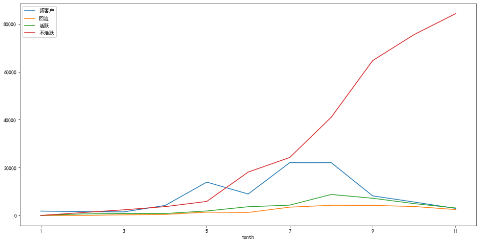

```python
purchase_cnt.T.plot(figsize=(16,8))
```

由于电子产品的特性，大多用户在购买一次之后呈现“不活跃”状态

### 帕累托分析

27%的用户贡献了80%的销售收入，符合二八法则，因此对于运营团队而言，需要对这27%的用户重点运营

```python
#查询每个用户的消费金额及累计消费金额

user_28 = data.groupby('user_id').agg(消费金额=('amount','sum')).sort_values('消费金额',ascending=False).reset_index()
user_28['累计销售额'] = user_28['消费金额'].cumsum()
user_28
```

|  | user_id | 消费金额 | 累计销售额 |
| --- | --- | --- | --- |
| 0 | 1515915625512422912.00 | 160604.07 | 160604.07 |
| 1 | 1515915625513695488.00 | 158277.37 | 318881.44 |
| 2 | 1515915625512377088.00 | 149967.06 | 468848.50 |
| 3 | 1515915625513577472.00 | 135672.84 | 604521.34 |
| 4 | 1515915625514597888.00 | 133945.88 | 738467.22 |
| ... | ... | ... | ... |
| 92750 | 1515915625511079936.00 | 0.02 | 114986635.82 |
| 92751 | 1515915625450548736.00 | 0.02 | 114986635.84 |
| 92752 | 1515915625506653440.00 | 0.02 | 114986635.86 |
| 92753 | 1515915625451367168.00 | 0.02 | 114986635.88 |
| 92754 | 1515915625468531712.00 | 0.00 | 114986635.88 |

92755 rows × 3 columns

```python
p = user_28['消费金额'].cumsum()/user_28['消费金额'].sum()  # 创建累计占比，Series
key = p[p>0.8].index[0]
key
```

```
25408
```

```python
key / user_28.shape[0]
```

```
0.2739259339119185
```

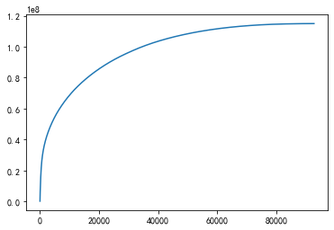

```python
plt.plot(user_28.index,user_28['累计销售额'])
plt.show()
```

### RFM用户分层

回忆一下RFM用户分层的定义：

R(Recency)：最近一次消费； F(Frequency)：消费频率； M(Monetary)：消费金额；

#### 计算每个用户的RFM值

```python
#先计算M
user_rfm = data.groupby(['user_id','datetime']).agg(消费金额=('amount','sum')).reset_index()
user_rfm.head()
```

|  | user_id | datetime | 消费金额 |
| --- | --- | --- | --- |
| 0 | 1515915625439951872.00 | 2020-07-09 06:35:18 | 416.64 |
| 1 | 1515915625440038400.00 | 2020-09-22 15:11:15 | 21.04 |
| 2 | 1515915625440038400.00 | 2020-10-28 05:53:47 | 35.39 |
| 3 | 1515915625440051712.00 | 2020-10-23 03:51:26 | 115.72 |
| 4 | 1515915625440051712.00 | 2020-10-23 06:38:11 | 428.22 |

```python
#然后计算F
user_rfm = user_rfm.groupby('user_id').agg(最后购买日期=('datetime','max')
                                           ,M=('消费金额','sum')
                                           ,F=('datetime','count')
                                          ).reset_index()
user_rfm
```

|  | user_id | 最后购买日期 | M | F |
| --- | --- | --- | --- | --- |
| 0 | 1515915625439951872.00 | 2020-07-09 06:35:18 | 416.64 | 1 |
| 1 | 1515915625440038400.00 | 2020-10-28 05:53:47 | 56.43 | 2 |
| 2 | 1515915625440051712.00 | 2020-11-16 15:49:50 | 7489.53 | 4 |
| 3 | 1515915625440099840.00 | 2020-11-08 23:48:43 | 4929.86 | 16 |
| 4 | 1515915625440121600.00 | 2020-07-14 13:04:12 | 182.83 | 2 |
| ... | ... | ... | ... | ... |
| 92750 | 1515915625514887424.00 | 2020-11-21 09:13:23 | 208.31 | 1 |
| 92751 | 1515915625514887936.00 | 2020-11-21 09:18:31 | 3472.20 | 1 |
| 92752 | 1515915625514888704.00 | 2020-11-21 10:10:01 | 752.49 | 3 |
| 92753 | 1515915625514891008.00 | 2020-11-21 10:04:42 | 925.67 | 1 |
| 92754 | 1515915625514891264.00 | 2020-11-21 10:10:13 | 418.96 | 1 |

92755 rows × 4 columns

```python
#然后计算R
user_rfm['最后购买日期'] = pd.to_datetime(user_rfm['最后购买日期'])
user_rfm['R'] = user_rfm['最后购买日期'].apply(lambda x:user_rfm['最后购买日期'].max() - x)
user_rfm['R'] = user_rfm['R'].dt.days
user_rfm = user_rfm[['user_id','R','F','M']]
user_rfm
```

|  | user_id | R | F | M |
| --- | --- | --- | --- | --- |
| 0 | 1515915625439951872.00 | 135 | 1 | 416.64 |
| 1 | 1515915625440038400.00 | 24 | 2 | 56.43 |
| 2 | 1515915625440051712.00 | 4 | 4 | 7489.53 |
| 3 | 1515915625440099840.00 | 12 | 16 | 4929.86 |
| 4 | 1515915625440121600.00 | 129 | 2 | 182.83 |
| ... | ... | ... | ... | ... |
| 92750 | 1515915625514887424.00 | 0 | 1 | 208.31 |
| 92751 | 1515915625514887936.00 | 0 | 1 | 3472.20 |
| 92752 | 1515915625514888704.00 | 0 | 3 | 752.49 |
| 92753 | 1515915625514891008.00 | 0 | 1 | 925.67 |
| 92754 | 1515915625514891264.00 | 0 | 1 | 418.96 |

92755 rows × 4 columns

#### 查看RFM的分布情况

```python
user_rfm['user_id'] = user_rfm['user_id'].astype('object')
user_rfm.describe(percentiles=(0.01,0.1,0.25,0.75,0.9,0.95,0.99)).T
```

|  | count | mean | std | min | 1% | 10% | 25% | 50% | 75% | 90% | 95% | 99% | max |
| --- | --- | --- | --- | --- | --- | --- | --- | --- | --- | --- | --- | --- | --- |
| R | 92755.00 | 98.11 | 54.55 | 0.00 | 1.00 | 23.00 | 60.00 | 100.00 | 127.00 | 179.00 | 195.00 | 211.00 | 321.00 |
| F | 92755.00 | 4.19 | 17.57 | 1.00 | 1.00 | 1.00 | 1.00 | 2.00 | 3.00 | 6.00 | 9.00 | 35.00 | 632.00 |
| M | 92755.00 | 1239.68 | 4129.72 | 0.00 | 6.00 | 41.64 | 148.11 | 456.89 | 1141.17 | 2402.53 | 3823.67 | 12744.87 | 160604.07 |

#### 根据分布对RFM分别打分

```python
R的打分:
[0-30]:5分
(30-60]:4分
(60-90]:3分
(90-120]:2分
120以上:1分

F的打分:
1次:1分
2次:2分
3次:3分
4次:4分
5次及以上:5分

M的打分:
[0-200]:1分
(200-500]:2分
(500-1000]:3分
(1000-2000]:4分
2000以上:5分

注：打分的情况其实没有固定的标准来衡量是否准确，所以可以依据数据的真实情况和自己判断来进行选择~
```

```python
rfm_score = user_rfm.copy()
for i,j in enumerate(rfm_score['R']):
    if j <= 30:
        rfm_score['R'][i] = 5
    elif j <= 60:
        rfm_score['R'][i] = 4
    elif j <= 90:
        rfm_score['R'][i] = 3
    elif j <= 120:
        rfm_score['R'][i] = 2
    else :
        rfm_score['R'][i] = 1

for i,j in enumerate(rfm_score['F']):
    if j <= 1:
        rfm_score['F'][i] = 1
    elif j <= 2:
        rfm_score['F'][i] = 2
    elif j <= 3:
        rfm_score['F'][i] = 3
    elif j <= 4:
        rfm_score['F'][i] = 4
    else :
        rfm_score['F'][i] = 5

for i,j in enumerate(rfm_score['M']):
    if j <= 200:
        rfm_score['M'][i] = 1
    elif j <= 500:
        rfm_score['M'][i] = 2
    elif j <= 1000:
        rfm_score['M'][i] = 3
    elif j <= 2000:
        rfm_score['M'][i] = 4
    else :
        rfm_score['M'][i] = 5
```

```python
rfm_score
```

|  | user_id | R | F | M |
| --- | --- | --- | --- | --- |
| 0 | 1515915625439951872.00 | 1 | 1 | 2.00 |
| 1 | 1515915625440038400.00 | 5 | 2 | 1.00 |
| 2 | 1515915625440051712.00 | 5 | 4 | 5.00 |
| 3 | 1515915625440099840.00 | 5 | 5 | 5.00 |
| 4 | 1515915625440121600.00 | 1 | 2 | 1.00 |
| ... | ... | ... | ... | ... |
| 92750 | 1515915625514887424.00 | 5 | 1 | 2.00 |
| 92751 | 1515915625514887936.00 | 5 | 1 | 5.00 |
| 92752 | 1515915625514888704.00 | 5 | 3 | 3.00 |
| 92753 | 1515915625514891008.00 | 5 | 1 | 3.00 |
| 92754 | 1515915625514891264.00 | 5 | 1 | 2.00 |

92755 rows × 4 columns

#### 计算RFM打分后的均值，然后判断RFM是0或是1

```python
rfm_score['R'].mean()
```

```
2.5114117837313352
```

```python
rfm_score['F'].mean()
```

```
2.3215999137512804
```

```python
rfm_score['M'].mean()
```

```
2.581930893213304
```

```python
rfm = pd.DataFrame()
rfm['user_id'] = rfm_score['user_id']
rfm['R'] = rfm_score['R'].apply(lambda x: '1' if x >= rfm_score['R'].mean() else '0')
rfm['F'] = rfm_score['F'].apply(lambda x: '1' if x >= rfm_score['F'].mean() else '0')
rfm['M'] = rfm_score['M'].apply(lambda x: '1' if x >= rfm_score['M'].mean() else '0')
rfm
```

|  | user_id | R | F | M |
| --- | --- | --- | --- | --- |
| 0 | 1515915625439951872.00 | 0 | 0 | 0 |
| 1 | 1515915625440038400.00 | 1 | 0 | 0 |
| 2 | 1515915625440051712.00 | 1 | 1 | 1 |
| 3 | 1515915625440099840.00 | 1 | 1 | 1 |
| 4 | 1515915625440121600.00 | 0 | 0 | 0 |
| ... | ... | ... | ... | ... |
| 92750 | 1515915625514887424.00 | 1 | 0 | 0 |
| 92751 | 1515915625514887936.00 | 1 | 0 | 1 |
| 92752 | 1515915625514888704.00 | 1 | 1 | 1 |
| 92753 | 1515915625514891008.00 | 1 | 0 | 1 |
| 92754 | 1515915625514891264.00 | 1 | 0 | 0 |

92755 rows × 4 columns

```python
rfm['result'] = rfm['R'] + rfm['F'] + rfm['M']
rfm
```

|  | user_id | R | F | M | result |
| --- | --- | --- | --- | --- | --- |
| 0 | 1515915625439951872.00 | 0 | 0 | 0 | 000 |
| 1 | 1515915625440038400.00 | 1 | 0 | 0 | 100 |
| 2 | 1515915625440051712.00 | 1 | 1 | 1 | 111 |
| 3 | 1515915625440099840.00 | 1 | 1 | 1 | 111 |
| 4 | 1515915625440121600.00 | 0 | 0 | 0 | 000 |
| ... | ... | ... | ... | ... | ... |
| 92750 | 1515915625514887424.00 | 1 | 0 | 0 | 100 |
| 92751 | 1515915625514887936.00 | 1 | 0 | 1 | 101 |
| 92752 | 1515915625514888704.00 | 1 | 1 | 1 | 111 |
| 92753 | 1515915625514891008.00 | 1 | 0 | 1 | 101 |
| 92754 | 1515915625514891264.00 | 1 | 0 | 0 | 100 |

92755 rows × 5 columns

#### 根据结果对用户进行分层

```python
for i,j in enumerate(rfm['result']):
    if j == '111':
        rfm['result'][i] = '重要价值客户'
    elif j == '101':
        rfm['result'][i] = '重要发展客户'
    elif j == '011':
        rfm['result'][i] = '重要保持客户'
    elif j == '001':
        rfm['result'][i] = '重要挽留客户'
    elif j == '110':
        rfm['result'][i] = '一般价值客户'
    elif j == '100':
        rfm['result'][i] = '一般发展客户'
    elif j == '010':
        rfm['result'][i] = '一般保持客户'
    elif j == '000':
        rfm['result'][i] = '一般挽留客户'
```

```python
rfm
```

|  | user_id | R | F | M | result |
| --- | --- | --- | --- | --- | --- |
| 0 | 1515915625439951872.00 | 0 | 0 | 0 | 一般挽留客户 |
| 1 | 1515915625440038400.00 | 1 | 0 | 0 | 一般发展客户 |
| 2 | 1515915625440051712.00 | 1 | 1 | 1 | 重要价值客户 |
| 3 | 1515915625440099840.00 | 1 | 1 | 1 | 重要价值客户 |
| 4 | 1515915625440121600.00 | 0 | 0 | 0 | 一般挽留客户 |
| ... | ... | ... | ... | ... | ... |
| 92750 | 1515915625514887424.00 | 1 | 0 | 0 | 一般发展客户 |
| 92751 | 1515915625514887936.00 | 1 | 0 | 1 | 重要发展客户 |
| 92752 | 1515915625514888704.00 | 1 | 1 | 1 | 重要价值客户 |
| 92753 | 1515915625514891008.00 | 1 | 0 | 1 | 重要发展客户 |
| 92754 | 1515915625514891264.00 | 1 | 0 | 0 | 一般发展客户 |

92755 rows × 5 columns

```python
rfm['result'].value_counts()
```

```
一般挽留客户    31360
重要价值客户    18127
一般发展客户    11500
重要挽留客户    10496
重要保持客户     9061
重要发展客户     6445
一般价值客户     2993
一般保持客户     2773
Name: result, dtype: int64
```

```
<function matplotlib.pyplot.show(close=None, block=None)>
```

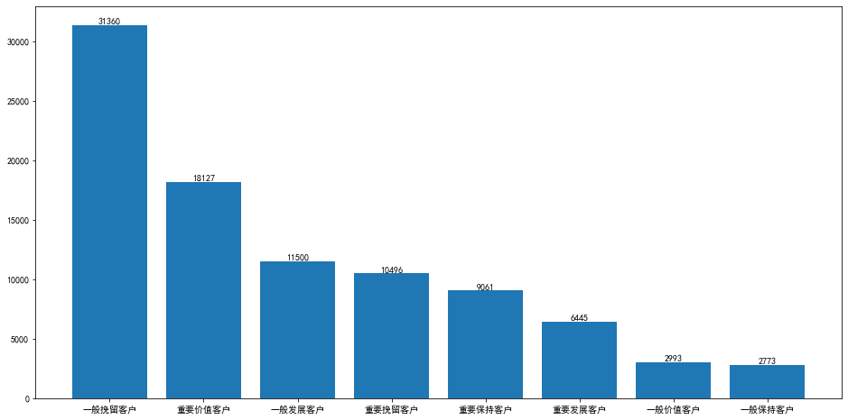

```python
plt.figure(figsize=(16,8))
plt.bar(rfm['result'].value_counts().index,rfm['result'].value_counts().values)
for x,y in enumerate(rfm['result'].value_counts()):
    plt.text(x,y+100,y,ha='center')
plt.show
```